Skip to content

Akif MustafaBiostatistician.

# Reverse Bayes, Robust Bayes, and Robust Reverse Bayes

A practical framework for examining prior sensitivity in clinical trials

Author

Akif Mustafa

Published

October 2, 2026

**Table of contents**

## Abstract

Bayesian analysis combines current data with prior information. This is its main strength. It is also the main source of criticism.

A posterior conclusion may depend on the prior. The useful question is therefore not whether the prior has influence. It should have influence. The useful question is whether that influence is transparent, justified, and stable under reasonable disagreement.

Three related approaches help answer that question.

**Reverse Bayes** starts from a posterior conclusion and works backward. It identifies the prior assumptions needed to support or overturn that conclusion.

**Robust Bayes** examines the posterior over a set of plausible priors. It asks whether the conclusion is stable when reasonable assumptions change.

**Robust reverse Bayes**, as the term is used here, combines the two. It locates the boundary between priors that support a decision and priors that do not. It then asks whether a scientifically credible prior lies on the other side of that boundary.

These approaches do not remove judgment from Bayesian analysis. They make judgment visible.

## 1 The central problem

A conventional Bayesian analysis moves in one direction:

$$\text{Prior information} + \text{Current data}
\longrightarrow \text{Posterior information}.$$

The prior describes uncertainty before the current data are observed. The likelihood represents the information in the current study. The posterior combines both.

Different experts hold different prior beliefs. Historical studies may not be fully relevant. A prior may be too optimistic. It may also be too skeptical. Even a prior described as “weakly informative” carries information, and that information can matter when the current study is small.

Prior sensitivity is therefore not a secondary technical issue. It is part of the scientific interpretation.

### 1.1 Three framings of prior sensitivity

A conventional analysis reports the posterior under one selected prior. It does not, by itself, address sensitivity. The three approaches below do.

Table 1: Three questions about prior sensitivity

| Approach | Main question |
| --- | --- |
| Reverse Bayes | What prior would be needed to produce or overturn a conclusion? |
| Robust Bayes | Is the conclusion stable over a credible set of priors? |
| Robust reverse Bayes | Where is the decision boundary, and does the credible set cross it? |

No single question gives a complete assessment.

The primary analysis supports the decision. The robust analysis assesses stability. The reverse analysis explains where the conclusion changes.

### 1.2 Reverse Bayesian reasoning

Reverse Bayes changes the direction of the question.

Suppose a trial is declared successful when

$$P(\theta > 0 \mid \text{data}) > 0.975 ,$$

where $\theta$ is the treatment effect and positive values represent benefit.

A conventional analysis selects a prior and computes this probability.

A reverse analysis asks instead:

> How skeptical would the prior need to be for the posterior probability to fall to 0.975?

The answer is a **critical prior**. It is also called a **tipping-point prior**.

A normal prior has two parameters. Either can be solved for while the other is held fixed.

- Fix the prior standard deviation and solve for the prior **mean**. The answer is the degree of prior pessimism required.
- Centre the prior at the null and solve for the prior **standard deviation**. The answer is the prior *precision* required. This is the form used by Good, by Matthews, and by Held and colleagues, and it is the more conventional of the two.

Both are reported for the example below.

The critical prior is not proposed as the true prior. It is a diagnostic quantity. Its purpose is to make the dependence of the conclusion visible.

The interpretation is direct.

- If a mildly skeptical prior overturns the result, the conclusion is fragile.
- If only an extreme prior overturns the result, the conclusion is more stable.
- If the critical prior is itself credible, prior disagreement may change the decision.
- If the critical prior is not credible, prior disagreement matters less.

Reverse Bayes therefore converts a posterior threshold into a scientific question about prior plausibility.

### 1.3 Robust Bayesian reasoning

Robust Bayes starts from a different concern.

A single prior may imply more precision than scientific knowledge supports. It may also conceal legitimate disagreement among experts.

A robust analysis specifies a set of priors,

$$\mathcal{P} = \{\text{priors considered scientifically credible}\},$$

repeats the analysis for every prior in the set, and examines the range of conclusions.

The set may vary:

- the prior mean;
- the prior variance;
- the effective sample size of historical information;
- the amount of dynamic borrowing;
- the assumed between-study heterogeneity;
- the prior probability of no effect or of harm;
- the tail behaviour of the prior.

A conclusion is robust when all, or nearly all, credible priors lead to the same substantive interpretation. It is not robust when credible priors lead to different decisions.

This does not mean every conceivable prior should be considered. An unrestricted set would include unreasonable assumptions. Robustness must be assessed over a justified set.

**Scope of the example**

The robust Bayesian literature, following Berger, works with broad non-parametric classes of priors. Common examples are $\varepsilon$-contamination classes, density-ratio classes, and classes defined by moment constraints. These allow the shape of the prior to vary, not only its parameters.

The example in this article varies two parameters within a single conjugate family. This is more properly described as a **parametric sensitivity analysis**. It is used because it can be displayed in two dimensions and understood without additional machinery.

The conceptual points carry over. The reassurance provided does not. A conclusion that is stable across a normal family may still be sensitive to prior shape, particularly to heavier tails, which change how prior-data conflict is resolved.

### 1.4 Robust reverse Bayes

The term **robust reverse Bayes** is not fully standardised. It is used here for a simple combination of the two ideas.

The procedure has three steps.

1. Define a class of scientifically credible priors.
2. Derive the prior boundary at which the decision changes.
3. Determine whether the credible class crosses that boundary.

The result has a clear visual interpretation.

- One region contains priors that lead to success.
- Another region contains priors that do not.
- The critical boundary separates the regions.
- The credible prior set is displayed on the same axes.

If the credible set lies entirely within one region, the decision is robust. If it crosses the boundary, the decision depends on unresolved prior assumptions.

This separates two issues that are often confused.

1. **Mathematical sensitivity.** Can some prior change the conclusion?
2. **Scientific sensitivity.** Can a credible prior change the conclusion?

Almost every Bayesian analysis is mathematically sensitive to a sufficiently extreme prior. The second question is the important one.

**Terminology**

“Reverse Bayes” and “robust Bayes” have established literatures. “Robust reverse Bayes” has less uniform usage.

In this article the term denotes a tipping-point analysis evaluated against a prespecified class of credible priors. It is not proposed as a new inferential framework.

## 2 An example

### 2.1 Trial result

Consider a two-arm trial with a continuous endpoint.

The estimated treatment effect is $0.30$. Its standard error is $0.12$. Positive values favour the experimental treatment.

For illustration, assume the estimate is approximately normally distributed around the true effect.

The likelihood alone suggests benefit. The purpose of the example is not to compare Bayesian and frequentist conclusions. The purpose is to examine how prior assumptions affect a formal Bayesian decision.

### 2.2 Primary prior

Suppose the primary analysis uses a normal prior centred at zero with standard deviation $0.20$.

The posterior is also normal. Under this prior:

- the posterior mean is 0.22;
- the posterior standard deviation is 0.10;
- the posterior probability of benefit is 98.4%.

The illustrative decision rule requires a posterior probability above 97.5%. The primary analysis meets the rule.

### 2.3 How much information does this prior contribute?

The prior is often described as “mildly skeptical”. That description is too comfortable. The contribution can be quantified.

Precision is additive under conjugate normal updating. The prior supplies 26.5% of the total posterior precision. Equivalently, it carries about 36% as much information as the trial itself.

The effect on the conclusion is visible. Under a flat prior the posterior probability of benefit would be 99.4%. The chosen prior reduces it to 98.4%.

The prior is doing real work. This is not an objection. It is the intended behaviour of a skeptical prior. It should nevertheless be stated numerically rather than asserted in words.

Any report that describes a prior only by an adjective should be treated as incomplete.

### 2.4 How the information is combined

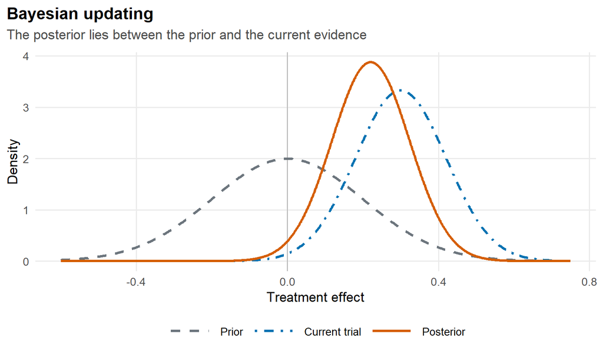

Figure 1: Prior information, current trial evidence, and the resulting posterior distribution.

The posterior is not an informal average of two opinions. Each source is weighted by its precision.

The prior pulls the estimate toward zero. The data pull it toward $0.30$. The posterior reflects both.

Figure 1 also shows why prior influence cannot be discussed without prior precision. A narrow prior has more influence than a broad prior with the same mean.

## 3 Reverse analysis of the example

### 3.1 Solving for the prior mean

Hold the prior standard deviation at $0.20$ and vary the prior mean.

The reverse question is:

> At what prior mean does the posterior probability of benefit equal 97.5%?

Here the critical prior mean is approximately -0.071.

The sign matters and should be stated plainly. The critical value is **negative**. To overturn the decision, an analyst would have to enter the trial expecting the treatment to be mildly *harmful*, with an expected effect of about -0.071 and a standard deviation of 0.20.

That is a stronger position than neutrality. A prior centred at zero is not sufficient to overturn the result. Nor is any prior centred on a positive effect, however small.

Whether a prior centred on harm is defensible is a clinical question. It may be reasonable for a treatment class with known toxicity, or where earlier compounds have failed. It is unlikely to be reasonable for a treatment with a plausible mechanism and no adverse history.

### 3.2 Solving for the prior standard deviation

The second form of the question holds the prior mean at the null and solves for the prior standard deviation.

> How *precise* would a null-centred prior have to be for the posterior probability to fall to 97.5%?

The answer is a prior standard deviation of approximately 0.152.

A margin this small is worth reporting explicitly. It would be concealed by a sensitivity analysis that reported only the primary prior and two or three alternatives.

### 3.3 Why the critical prior is useful

The statement “the result is sensitive to the prior” is incomplete.

Every posterior is sensitive to some prior. The useful questions are:

- How much skepticism is required?
- How precise must that skeptical prior be?
- Is such a prior scientifically plausible?
- Would relevant experts have endorsed it before the data were observed?

The critical prior makes these questions concrete.

## 4 Robust analysis of the example

### 4.1 Defining a credible prior set

Suppose elicitation supports the following ranges:

- prior means from $-0.10$ to $0.10$;
- prior standard deviations from $0.15$ to $0.35$.

The set includes both skeptical and optimistic means, and several levels of prior precision.

These limits should be justified before the outcome data are examined. They are illustrative here.

Across this set the posterior probability of benefit ranges from about 93.8% to 99.3%.

The lower limit falls below the 97.5% rule. About 9% of the set fails the rule, concentrated where the prior is both skeptical and precise.

### 4.2 Two conclusions, not one

The correct summary depends on which conclusion is being assessed.

The **substantive** conclusion is robust. Every prior in the credible set gives a posterior probability of benefit above 93.8%. No credible prior supports a belief that the treatment is ineffective.

The **formal** conclusion is not robust. The 97.5% threshold is crossed within the credible set. A prespecified rule applied mechanically would succeed or fail depending on which prior had been selected in the protocol.

These should not be reported as the same finding. An analysis can be threshold-fragile and interpretation-stable at once. That combination is common, and it usually says more about the threshold than about the evidence.

### 4.3 A map of prior sensitivity

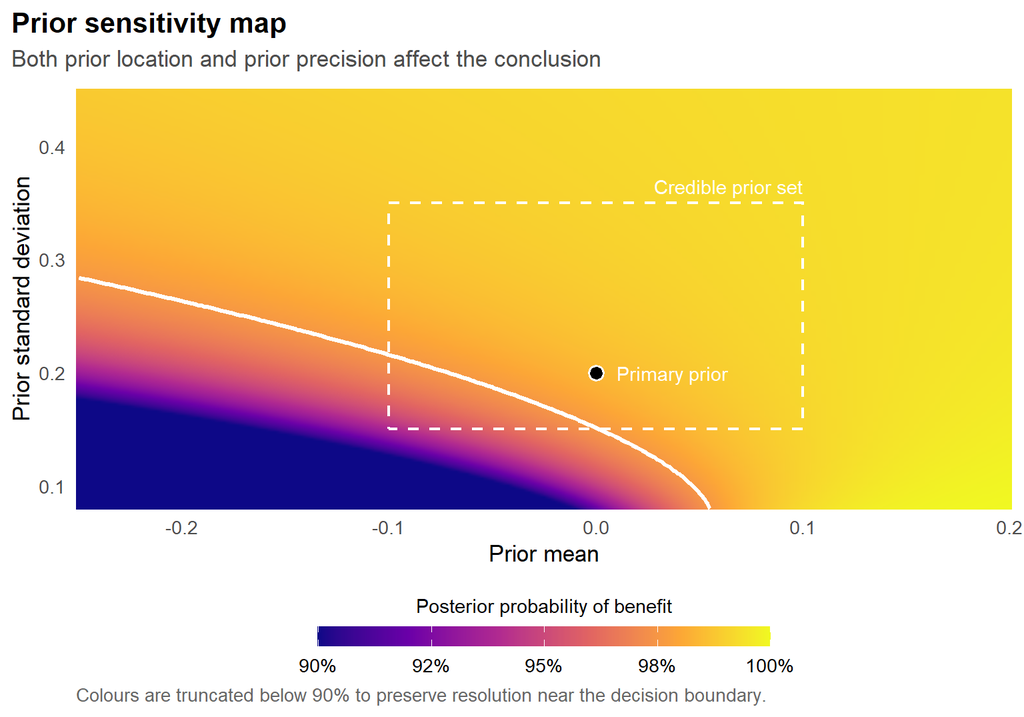

Figure 2: Posterior probability of benefit across a wide range of normal priors. The white contour marks the 97.5% decision boundary. The dashed rectangle is the prespecified credible set, which the boundary crosses near its lower left corner.

Figure 2 shows the credible set against the wider space of normal priors, so that the question “does the boundary cross the set?” can be answered by inspection. It does, near the lower left corner, where the prior is both skeptical and precise.

The horizontal axis is the prior mean. Moving right makes the prior more optimistic. Moving left makes it more skeptical.

The vertical axis is the prior standard deviation. Moving up makes the prior less precise. Moving down makes it more precise.

**A feature of this example, not a general rule**

In this figure, widening the prior always *increases* the posterior probability of benefit. This is not a general property of Bayesian updating.

It holds here because every prior mean considered lies below the observed estimate of 0.30. A less precise prior therefore pulls the posterior downward less, and the probability of benefit rises.

Had the credible set included prior means above 0.30, the direction would reverse in that region. Widening an optimistic prior would then reduce the probability of benefit.

“Less precise” and “more favourable” coincide here only because all the priors under consideration are less optimistic than the data. The general statement is narrower: a broader prior moves the posterior toward the likelihood, in whichever direction that happens to lie.

A skeptical and precise prior has a strong effect. A skeptical but broad prior has less effect, because it contributes less information.

This interaction matters. The label “skeptical prior” is not sufficient. Location and precision must both be reported.

## 5 The robust reverse view

The heat map computes posterior probabilities for many priors. A reverse analysis summarises the same issue more directly.

For each prior standard deviation, compute the prior mean that gives a posterior probability of exactly 97.5%.

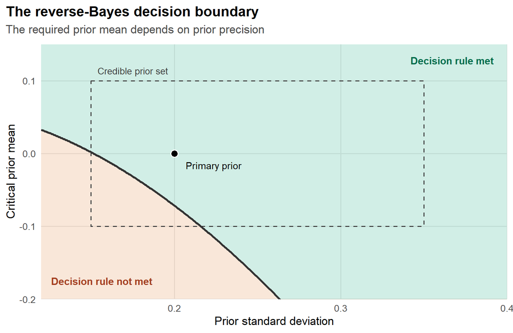

Figure 3: Critical prior mean as a function of prior uncertainty. Prior means above the curve meet the illustrative decision rule. The vertical axis is clipped at -0.20 for legibility; the curve continues downward, reaching about -0.61 at a prior standard deviation of 0.40.

Figure 3 is the robust reverse-Bayes view.

The curve is not a second decision rule. It describes the first decision rule in the space of prior assumptions.

The green region contains prior combinations that meet the rule. The orange region contains those that do not. The dashed rectangle is the credible set, shown on the same axes so that the intersection is visible.

The intersection is small and confined to the left edge of the set, where the prior is tightest. Everywhere else the credible set lies in the green region.

The figure illustrates one principle clearly:

> A prior cannot be described by its mean alone.

A strongly skeptical prior may have little effect if it is very uncertain. A moderately skeptical prior may have a large effect if it is highly precise.

The relevant object is therefore a boundary over several prior characteristics, not a single critical number.

## 6 Philosophical interpretation

### 6.1 The prior is part of the model

A prior is not an external adjustment applied after the analysis. It is part of the statistical model.

The likelihood also contains assumptions. These may concern sampling, censoring, missing data, proportional hazards, measurement error, or the endpoint distribution.

Prior sensitivity should therefore sit inside the broader problem of model sensitivity.

A posterior conclusion may be unstable because of:

- the prior;
- the likelihood;
- missing-data assumptions;
- the endpoint definition;
- borrowing assumptions;
- treatment-effect heterogeneity;
- the decision threshold.

A complete robustness assessment does not scrutinise the prior while treating everything else as certain.

### 6.2 Robustness is not prior shopping

Sensitivity analysis can be misused. An analyst may fit several priors and report the one that gives the preferred conclusion. That is selective reporting, not robust Bayesian practice.

A defensible process requires:

1. a prespecified primary prior;
2. a scientifically justified set of alternative priors;
3. a prespecified decision rule;
4. complete reporting of all planned analyses;
5. clear separation of confirmatory and exploratory results.

The purpose of a robust analysis is not to find the most favourable prior. It is to determine whether reasonable disagreement changes the conclusion.

### 6.3 One prior or several priors?

There are two broad approaches to uncertain prior information.

The first specifies several priors and treats them as sensitivity analyses. The second represents the uncertainty inside one larger model, such as a mixture prior or a hierarchical prior.

Neither is universally superior.

A single hierarchical or mixture prior gives one coherent posterior analysis. It can also let the data modify the degree of borrowing.

A class of priors makes disagreement visible. It does not force several scientific positions into one distribution.

The choice depends on the purpose.

- For a single formal decision, one prespecified model is usually necessary.
- For understanding the consequences of scientific disagreement, a class of priors is more informative.
- When both aims apply, the primary model and the robustness analysis should keep distinct roles.

### 6.4 Robustness does not mean invariance

No conclusion is invariant to every assumption. A sufficiently precise prior can dominate almost any finite dataset.

Robustness should mean stability under a defined set of credible assumptions. The word **credible** is essential. Its meaning must come from subject-matter knowledge, not from the observed result.

### 6.5 Reverse Bayes does not identify the correct prior

The critical prior is a mathematical boundary. It is not an estimate of what experts believed before the trial. It does not replace formal elicitation.

Its role is diagnostic. It shows what would have to be believed for the conclusion to change.

This distinction prevents a common error. A reverse analysis can always find some prior that overturns a result. The existence of that prior does not establish fragility. The prior must also be scientifically defensible.

## 7 Implications for clinical studies

### 7.1 Historical borrowing

Prior sensitivity matters most when external data contribute to the primary analysis.

Historical controls may differ from current controls because of:

- changes in standard of care;
- changes in patient selection;
- regional differences;
- improved supportive treatment;
- changes in endpoint assessment;
- unmeasured prognostic factors.

A robust analysis can vary the amount of borrowing. A reverse analysis can ask how much discounting is needed to change the decision. A robust reverse analysis can display the boundary over both historical compatibility and borrowing strength.

### 7.2 Small populations

In rare diseases, the prior may represent a large share of the total information.

This does not make Bayesian analysis inappropriate. It makes transparency more important.

The report should show:

- where the prior information came from;
- how relevant it is to the current population;
- how much effective information it contributes;
- how prior-data conflict is handled;
- whether credible alternative priors change the decision.

### 7.3 Adaptive decisions

Bayesian designs often support interim decisions on stopping, dose selection, or sample-size adaptation.

Reverse and robust reasoning apply here as well. The assessment should be made by simulation before the trial.

A fixed-data posterior sensitivity analysis does not describe the behaviour of an adaptive design. The design should be evaluated over a range of true treatment effects and degrees of prior-data conflict.

Relevant operating characteristics include:

- probability of declaring benefit;
- probability of stopping for futility;
- expected sample size;
- bias after early stopping;
- treatment allocation;
- probability of selecting the correct dose;
- behaviour under prior-data conflict.

## 8 Questions for critical review

### 8.1 About the primary prior

- Was the prior specified before outcome data were examined?
- Is its location clinically interpretable?
- Is its precision justified?
- What share of the posterior precision does it supply?
- Does it assign reasonable probability to benefit, no effect, and harm?

### 8.2 About the robust analysis

- Was the class of priors prespecified?
- Does it represent genuine scientific disagreement?
- Does it vary prior shape, or only prior parameters?
- Are both optimistic and skeptical assumptions included?
- Are all planned results reported?

### 8.3 About the reverse analysis

- Which prior overturns the conclusion, and in which direction?
- How precise must that prior be?
- How close does the critical prior lie to the edge of the credible set?
- Is the critical prior scientifically credible?
- Would experts have endorsed it before seeing the data?

### 8.4 About the decision

- Is the threshold clinically and scientifically justified?
- Is the substantive interpretation stable even where the threshold is not?
- Is the conclusion stable to likelihood assumptions?
- Does the decision rest mainly on current data or on external information?
- What are the consequences of a false positive and of a false negative?

## 9 Limitations of the example

The example is deliberately simple. It uses one treatment effect, a normal likelihood, a normal prior, and no nuisance parameters, missing data, multiplicity, interim analyses, or prior-data conflict model.

It also varies only two prior parameters within one family. As noted above, this is a parametric sensitivity analysis rather than a robust Bayesian analysis in the non-parametric sense.

Real trials are more complex.

The simple model is still useful, because it isolates the main idea. Reverse and robust reasoning are not tied to the normal model. They extend to binary, survival, longitudinal, and hierarchical settings.

In complex settings the critical boundary may need numerical computation or simulation. The conceptual questions do not change.

1. Which assumptions support the decision?
2. Which assumptions overturn it?
3. Which of those assumptions are scientifically credible?

## References

Berger, J. O. (1994). An overview of robust Bayesian analysis. *Test*, 3, 5–124.

Good, I. J. (1950). *Probability and the Weighing of Evidence*. Charles Griffin.

Held, L., Matthews, R., Ott, M., and Pawel, S. (2022). Reverse-Bayes methods for evidence assessment and research synthesis. *Research Synthesis Methods*, 13, 295–314.

Matthews, R. A. J. (2001). Why should clinicians care about Bayesian methods? *Journal of Statistical Planning and Inference*, 94, 43–58.

O’Hagan, A., Buck, C. E., Daneshkhah, A., Eiser, J. R., Garthwaite, P. H., Jenkinson, D. J., Oakley, J. E., and Rakow, T. (2006). *Uncertain Judgements: Eliciting Experts’ Probabilities*. Wiley.

Spiegelhalter, D. J., Abrams, K. R., and Myles, J. P. (2004). *Bayesian Approaches to Clinical Trials and Health-Care Evaluation*. Wiley.